# p-value retirement?

24 April 2023

## what is a p-value?

- a p-value is the (worst-case) probability of obtaining a test statistic at least as extreme as the observed one (in a hypothetical repetition of the study), assuming that model and null hypothesis are correct
- mathematically, it is a conditional probability: that is, a random (i.e. data-dependent) probability value
- it is typically uniformly distributed on the interval [0,1] under the null hypothesis, while more concentrated towards 0 under the alternative hypothesis
- hence, small p-values correspond to statistical evidence in favor of the alternative hypothesis vs the null hypothesis

## why retiring the p-value?

- it is important to distinguish between p-value and statistical significance (p<0.05)
- the latter is criticized much more than the former
- the word “significance” is problematic because of its general meaning (but statistical significance depends on the sample size, while real-world significance does not)
- the real problem is dichotomizing p-values and attaching too much importance to statistical significance (see examples of [craving for significance](http://mchankins.wordpress.com/2013/04/21/still-not-significant-2))
- unfortunately, how papers are read is more important than how they are written

## Bayesianism as alternative?

- the main problem of p-values is their misuse: unfortunately, misuse of Bayesian methods is not better than misuse of frequentist ones
- the standard Bayesian statistical approach require a subjective prior and delivers a subjective posterior, which may suit better exploratory than confirmatory research
- ignorance cannot be expressed by a probabilistic prior: this is the main reason for the development of classical statistics

## is there a reproducibility crisis?

[figure not shown]

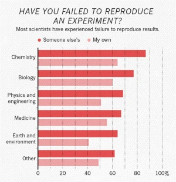

Baker: Is there a reproducibility crisis? [Nature, 2016]

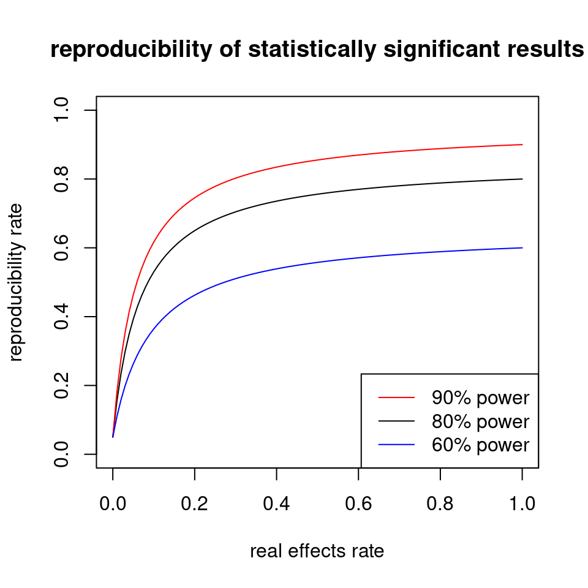

## accept uncertainty!

- deduction: All men are mortal. Socrates is a man. Therefore, Socrates is mortal.
- induction: Will the sun rise tomorrow?
- statistical significance is often misused to obtain certainty from induction, which is impossible
- a central tenet of classical statistics is placing bounds on the probability of wrong conclusions
- the significance level is a bound on the probability of false positives

## plan ahead and be transparent!

[figure not shown]

- writing a statistical analysis plan (before looking at the data) helps against questionable research practices such as p-hacking and data dredging  
  \(\qquad\)if you torture the data enough, nature will always confess [Coase, 1982]
- sensitivity analyses help assessing the robustness and credibility of the results  
  \(\qquad\)all models are wrong, but some are useful [Box, 1987]

## report estimates and uncertainty!

- standard reporting format for effect size: \(~\) **estimate \({}\) [95% CI] \({}\) p-value**
- CIs express also statistical significance, but are rarely criticized

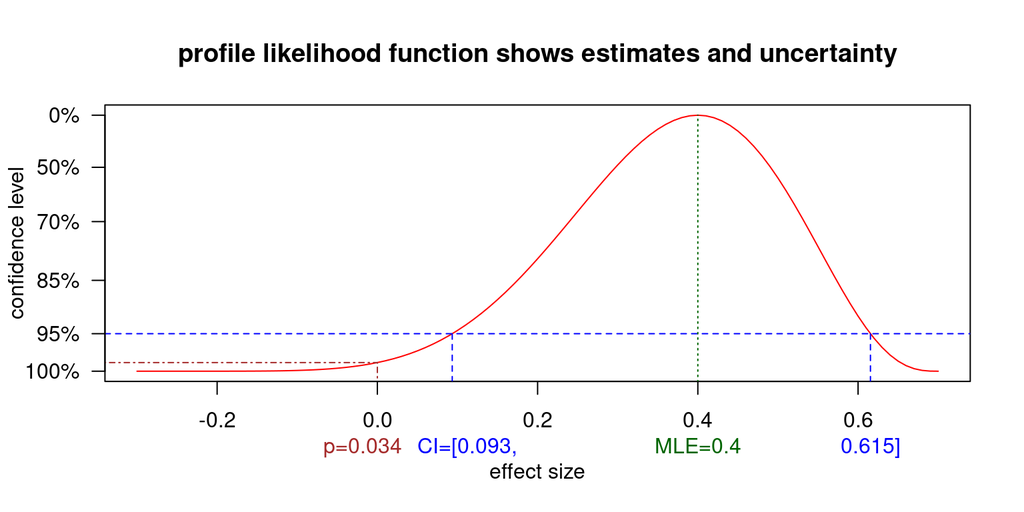

## ASA statement on p-values: principles

- p-values can indicate how incompatible the data are with a specified statistical model [and the null hypothesis]
- p-values do not measure the probability that the studied hypothesis is true, or the probability that the data were produced by random chance alone
- scientific conclusions and business [?] or policy decisions should not be based only on whether a p-value passes a specific threshold
- proper inference requires full reporting and transparency [but synthesis is also important]
- a p-value, or statistical significance, does not measure the size of an effect or the importance of a result
- by itself, a p-value does not provide a good measure of evidence regarding a model or hypothesis [sensitivity analyses are essential]

## summary

- problems of p-values:
  - their dichotomization and the emphasis on statistical significance
  - there is no real alternative (any measure of evidence can be misused)
  - how papers are written and most importantly read  
    \({}\)
- how to work with p-values:
  - accept uncertainty
  - plan ahead and be transparent
  - report estimates and uncertainty